# Уровень каких белков различается в мышиной модели синдрома Дауна

Библиотеки, которые необходимы для выполнения данного проекта **ggplot2**, **dplyr**, **lmtest**, **gdata**, **car**, **vegan**, **factoextra**, **pca3d**, **multcomp**, **gridExtra**:

# 1. Описание датасета.

В эксперименте участвовало 72 мыши: 34 с синдромом Дауна и 38 контрольных. На каждую мышь было проведено по 15 измерений уровня экспрессии белков. Каждое измерение белков имеет свой идентификатор, обозначаемый *MouseID* (всего 1080 различных измерений). 77 различных белков были задетектированы из ядерной фракции коры. Все мыши были поделены на 8 классов по трем признакам: генотип (*Genotype*: с синдромом Дауна – *Ts65Dn*, без синдрома Дауна – *Control*), лечение (*Treatment*: с лекарством, восстанавливающим способность к обучению – *Memantine*, без лекарства – *Saline*), поведение (*Behavior*: стимулированные к обучению – *C/S*, без стимуляции – *S/C*). Соответственно классы:

c-CS-s: контрольные мыши, стимулированные к обучению, инъецированные физиологическим раствором (9 мышей)

c-CS-m: контрольные мыши, стимулированные к обучению, инъецированные лекарством (10 мышей)

c-SC-s: контрольные мыши, не стимулированные к обучению, инъецированные физиологическим раствором (9 мышей)

c-SC-m: контрольные мыши, не стимулированные к обучению, инъецированные лекарством (10 мышей)

t-CS-s: трисомные мыши, стимулированные к обучению, инъецированные физиологическим раствором (7 мышей)

t-CS-m: трисомные мыши, стимулированные к обучению, инъецированные лекарством (9 мышей)

t-SC-s: мыши с трисомией, не стимулированные к обучению, инъецированные физиологическим раствором (9 мышей)

t-SC-m: трисомные мыши, не стимулированные к обучению, инъецированные лекарством (9 мышей)

Для начала посмотрим на структуру данных:

```r
str(data)
```

```
## 'data.frame':    1080 obs. of  82 variables:
##  $ MouseID        : Factor w/ 1080 levels "18899_1","18899_10",..: 46 53 54 55 56 57 58 59 60 47 ...
##  $ DYRK1A_N       : num  0.504 0.515 0.509 0.442 0.435 ...
##  $ ITSN1_N        : num  0.747 0.689 0.73 0.617 0.617 ...
##  $ BDNF_N         : num  0.43 0.412 0.418 0.359 0.359 ...
##  $ NR1_N          : num  2.82 2.79 2.69 2.47 2.37 ...
##  $ NR2A_N         : num  5.99 5.69 5.62 4.98 4.72 ...
##  $ pAKT_N         : num  0.219 0.212 0.209 0.223 0.213 ...
##  $ pBRAF_N        : num  0.178 0.173 0.176 0.176 0.174 ...
##  $ pCAMKII_N      : num  2.37 2.29 2.28 2.15 2.13 ...
##  $ pCREB_N        : num  0.232 0.227 0.23 0.207 0.192 ...
##  $ pELK_N         : num  1.75 1.6 1.56 1.6 1.5 ...
##  $ pERK_N         : num  0.688 0.695 0.677 0.583 0.551 ...
##  $ pJNK_N         : num  0.306 0.299 0.291 0.297 0.287 ...
##  $ PKCA_N         : num  0.403 0.386 0.381 0.377 0.364 ...
```

[output cut: 68 more lines]

Количество полных наблюдений: 552

Можно заметить, что в датасете есть предикторы, в которых слишком много NA (это может быть связано с тем, что для некоторых образцов уровень экспрессии некоторых белков было сложно или невозможно померить, может быть закончились реактивы). Чтобы не удалять половину датасета, удалим сначала предикторы, обозначающие такие белки, уровень экспрессии которых не был измерен хотя бы для 50 образцов.

```r
col.has.na <- apply(data, 2, function(x){(sum(is.na(x)) > 50)})
# sum(col.has.na)
data.filtered <- data[,!col.has.na]
```

Таким образом, мы удалили 6 предикторов. В таком датасете количество полных наблюдений: 1047. Остальные наблюдения с NA удалим (их мало, поэтому будем ими жертвовать во имя честного анализа).

```r
data <- na.omit(data.filtered)
```

# 2. Есть ли различия в уровне продукции BDNF_N в зависимости от класса в эксперименте?

## 2.1 Предварительный анализ

Чтобы ответить на поставленный вопрос, мы проведем дисперсионный анализ. Но для начала попробуем посмотрим на следующий график зависимости экспрессии белка от класса образца.

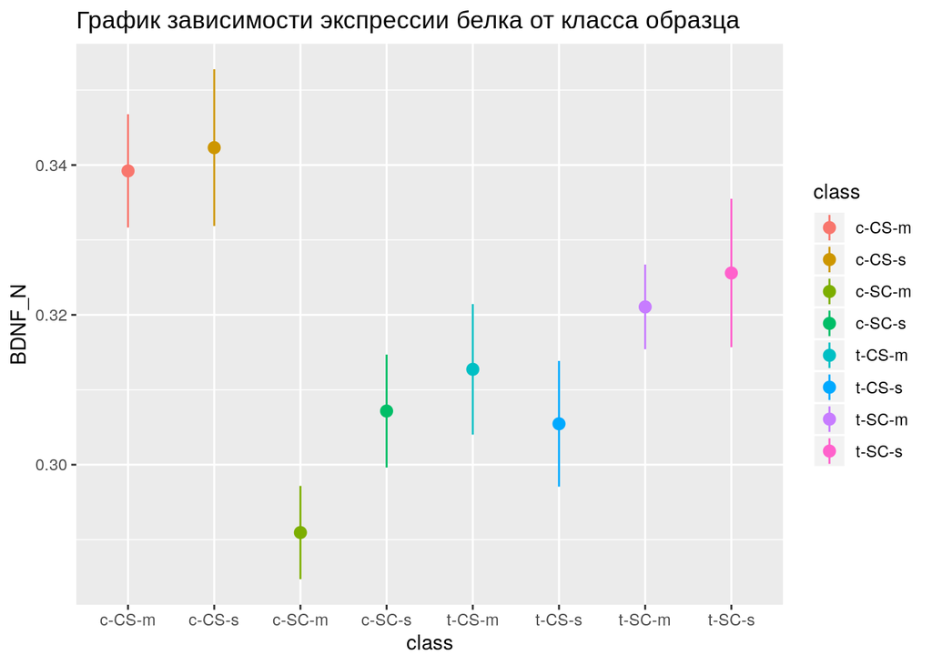

```r
ggplot(data, aes(class, BDNF_N, color = class)) + stat_summary(fun.data = "mean_cl_normal") + ggtitle(label = "График зависимости экспрессии белка от класса образца")
```

Судя по графику, есть классы и их группы, для которых уровень экспрессии BDNF_N может значимо отличаться (особенно явно это видно для c-SC-m). Попробуем проверить это, проведя дисперсионный анализ.

## 2.2. Дисперсионный анализ

### 2.2.1. Проверка условий применимости

Для того, чтобы воспользоваться функцией **anova** нам необходимо проверить, что соблюдаются некоторые условия.

#### 2.2.1.1. Нормальное распределение остатков

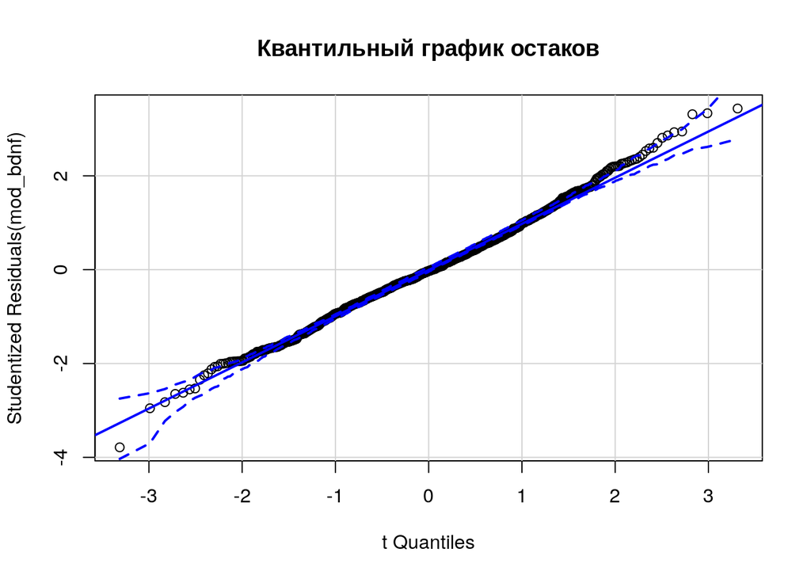

```r
mod_bdnf <- lm(BDNF_N ~ class, data)
qqPlot(mod_bdnf, id = FALSE, main = "Квантильный график остаков")
```

По графику видно, что это условие соблюдено.

#### 2.2.1.2. Гомогенность дисперсий остатков

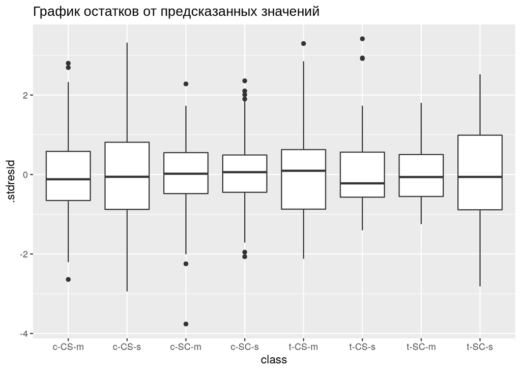

```r
mod_diag <- fortify(mod_bdnf)
ggplot(mod_diag, aes(x = class, y = .stdresid)) + geom_boxplot() + ggtitle("График остатков от предсказанных значений")
```

В целом, разброс дисперсий в пределах нормы.

#### 2.2.1.3. Отсутствие коллинеарности (независимость групп)

По построению эксперимента, группы являются независимыми.

#### 2.2.1.4. Случайность и независимость наблюдений в группах

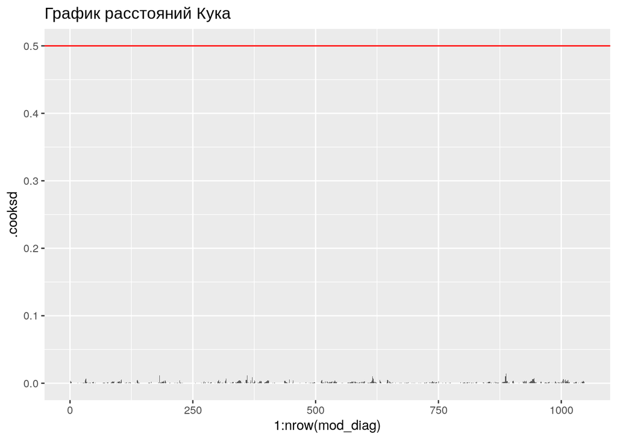

```r
ggplot(mod_diag, aes(x = 1:nrow(mod_diag), y = .cooksd)) +
  geom_bar(stat = "identity") +
  ggtitle("График расстояний Кука") +
  geom_hline(yintercept = 0.5, color = "red")
```

По графику видно, что влиятельных наблюдений у нас нет.

### 2.2.2 ANOVA

```r
bdnf_anova <- Anova(mod_bdnf)
bdnf_anova
```

```
## Anova Table (Type II tests)
##
## Response: BDNF_N
##            Sum Sq   Df F value    Pr(>F)
## class     0.29147    7  18.951 < 2.2e-16 ***
## Residuals 2.28279 1039
## ---
## Signif. codes:  0 '***' 0.001 '**' 0.01 '*' 0.05 '.' 0.1 ' ' 1
```

Видим, что уровень экспрессии белка BDNF_N значимо зависит от класса образца (F =18.9513558 , p_value = 6.4821210^{-24}, df_1 = 7, df_2 = 1039).

## 2.3. Пост-хок тест Тьюки

Для выявления попарных различий проведем пост-хок тест Тьюки.

```r
post_hoch <- glht(mod_bdnf, linfct = mcp(class = "Tukey"))
result <- summary(post_hoch)
result
```

```
##
##   Simultaneous Tests for General Linear Hypotheses
##
## Multiple Comparisons of Means: Tukey Contrasts
##
##
## Fit: lm(formula = BDNF_N ~ class, data = data)
##
## Linear Hypotheses:
##                       Estimate Std. Error t value Pr(>|t|)
## c-CS-s - c-CS-m == 0  0.003099   0.005741   0.540   0.9994
## c-SC-m - c-CS-m == 0 -0.048272   0.005412  -8.919    <0.01 ***
## c-SC-s - c-CS-m == 0 -0.032054   0.005741  -5.584    <0.01 ***
## t-CS-m - c-CS-m == 0 -0.026485   0.005561  -4.763    <0.01 ***
## t-CS-s - c-CS-m == 0 -0.033757   0.005964  -5.660    <0.01 ***
## t-SC-m - c-CS-m == 0 -0.018154   0.005561  -3.265   0.0250 *
## t-SC-s - c-CS-m == 0 -0.013631   0.005594  -2.437   0.2243
## c-SC-m - c-CS-s == 0 -0.051371   0.005741  -8.948    <0.01 ***
## c-SC-s - c-CS-s == 0 -0.035153   0.006051  -5.809    <0.01 ***
## t-CS-m - c-CS-s == 0 -0.029584   0.005881  -5.031    <0.01 ***
## t-CS-s - c-CS-s == 0 -0.036856   0.006264  -5.884    <0.01 ***
## t-SC-m - c-CS-s == 0 -0.021253   0.005881  -3.614    <0.01 **
## t-SC-s - c-CS-s == 0 -0.016730   0.005912  -2.830   0.0886 .
## c-SC-s - c-SC-m == 0  0.016218   0.005741   2.825   0.0892 .
## t-CS-m - c-SC-m == 0  0.021786   0.005561   3.918    <0.01 **
## t-CS-s - c-SC-m == 0  0.014515   0.005964   2.434   0.2259
## t-SC-m - c-SC-m == 0  0.030118   0.005561   5.416    <0.01 ***
## t-SC-s - c-SC-m == 0  0.034641   0.005594   6.193    <0.01 ***
## t-CS-m - c-SC-s == 0  0.005569   0.005881   0.947   0.9812
## t-CS-s - c-SC-s == 0 -0.001703   0.006264  -0.272   1.0000
## t-SC-m - c-SC-s == 0  0.013900   0.005881   2.364   0.2598
## t-SC-s - c-SC-s == 0  0.018423   0.005912   3.116   0.0395 *
## t-CS-s - t-CS-m == 0 -0.007272   0.006099  -1.192   0.9340
## t-SC-m - t-CS-m == 0  0.008331   0.005705   1.460   0.8279
## t-SC-s - t-CS-m == 0  0.012854   0.005738   2.240   0.3274
## t-SC-m - t-CS-s == 0  0.015603   0.006099   2.558   0.1719
## t-SC-s - t-CS-s == 0  0.020126   0.006129   3.284   0.0233 *
## t-SC-s - t-SC-m == 0  0.004523   0.005738   0.788   0.9937
## ---
## Signif. codes:  0 '***' 0.001 '**' 0.01 '*' 0.05 '.' 0.1 ' ' 1
## (Adjusted p values reported -- single-step method)
```

Уровень экспрессии BDNF_N в классе c-CS-m значимо выше, чем в группе c-SC-m (F = -0.0482717, p_value = 0 ), чем в классе c-SC-s (F = -0.0320541, p_value = 4.024392810^{-7}), чем в классе t-CS-m (F = -0.0264852, p_value = 4.469909510^{-5}), чем в классе t-CS-s (F = -0.033757, p_value = 1.186798810^{-6}), чем в классе t-SC-m (F = -0.0181541, p_value = 0.024978).

Но также есть значимые различия и для других пар. Все F и p-значения можно найти в таблице выше.

В полученной таблице много результатов, чтобы удобнее их анализировать, используем визуализацию.

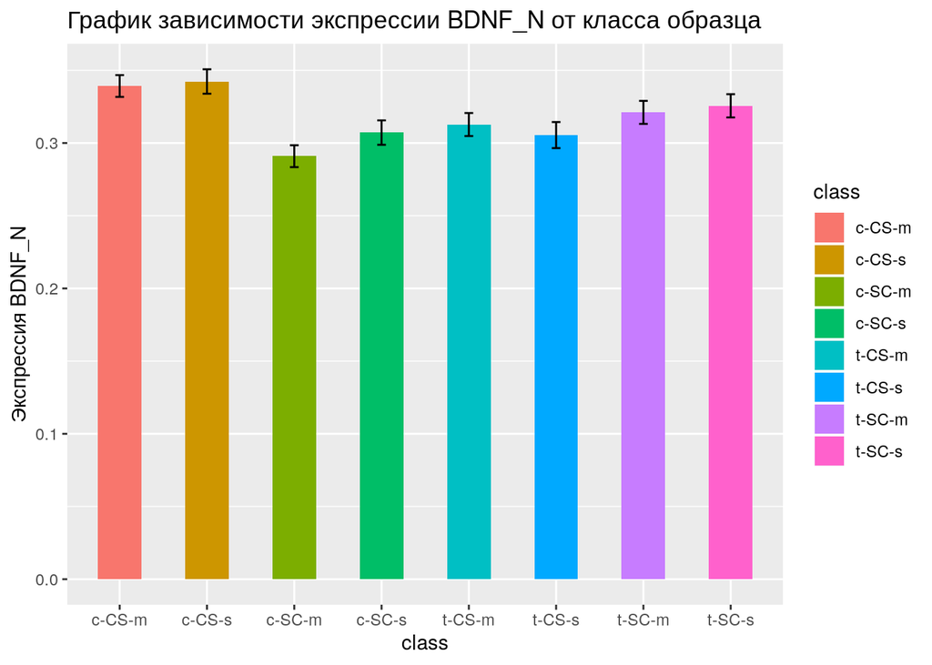

```r
MyData <- data.frame(class = factor(levels(data$class), levels = levels(data$class)))
MyData <- data.frame(MyData,
  predict(mod_bdnf, newdata = MyData, interval = "confidence")
)

gg_bars <- ggplot(data = MyData, aes(x = class, y = fit)) +
  geom_bar(stat = "identity", aes(fill = class), width = 0.5) +
  geom_errorbar(aes(ymin = lwr, ymax = upr), width = 0.1)

gg_bars + ggtitle(label = "График зависимости экспрессии BDNF_N от класса образца") + ylab(label = "Экспрессия BDNF_N")
```

# 3. Линейная модель для BDNF_N в зависимости от данных о других белках.

## 3.1. Построение модели

Построим полную модель зависимости уровня экспрессии белка BDNF_N от уровня экспрессии других белков.

```r
model_full <- lm(BDNF_N ~ . - MouseID - Genotype - Treatment - Behavior - class, data)
summary(model_full)
```

```
##
## Call:
## lm(formula = BDNF_N ~ . - MouseID - Genotype - Treatment - Behavior -
##     class, data = data)
##
## Residuals:
##       Min        1Q    Median        3Q       Max
## -0.139187 -0.008146 -0.000869  0.006203  0.100143
##
## Coefficients: (1 not defined because of singularities)
##                   Estimate Std. Error t value Pr(>|t|)
## (Intercept)     -2.411e-02  1.262e-02  -1.911 0.056301 .
## DYRK1A_N         1.508e-02  1.192e-02   1.265 0.206050
## ITSN1_N         -2.675e-02  1.330e-02  -2.011 0.044611 *
## NR1_N           -1.334e-02  8.642e-03  -1.544 0.122909
## NR2A_N           1.786e-04  2.207e-03   0.081 0.935489
## pAKT_N          -7.237e-02  3.431e-02  -2.109 0.035184 *
## pBRAF_N          1.168e-01  4.942e-02   2.363 0.018314 *
## pCAMKII_N        1.025e-03  1.020e-03   1.005 0.314958
## pCREB_N          7.324e-02  4.439e-02   1.650 0.099307 .
## pELK_N          -3.263e-04  2.134e-03  -0.153 0.878508
## pERK_N           2.333e-03  5.780e-03   0.404 0.686628
## pJNK_N          -1.665e-01  3.723e-02  -4.473 8.62e-06 ***
## PKCA_N           7.879e-02  3.539e-02   2.226 0.026208 *
## pMEK_N           6.293e-02  3.654e-02   1.722 0.085313 .
## pNR1_N           9.549e-03  1.975e-02   0.483 0.628880
## pNR2A_N         -9.411e-03  9.707e-03  -0.969 0.332563
## pNR2B_N         -1.383e-02  8.378e-03  -1.650 0.099231 .
## pPKCAB_N         7.155e-03  4.205e-03   1.701 0.089178 .
## pRSK_N          -8.786e-03  1.985e-02  -0.443 0.658215
## AKT_N           -4.473e-02  1.383e-02  -3.235 0.001256 **
## BRAF_N           9.552e-03  1.517e-02   0.630 0.529111
## CAMKII_N         7.833e-02  3.034e-02   2.582 0.009976 **
## CREB_N           1.388e-01  4.464e-02   3.109 0.001931 **
## ELK_N            4.424e-02  5.976e-03   7.402 2.89e-13 ***
## ERK_N            1.399e-02  3.715e-03   3.767 0.000175 ***
## GSK3B_N          8.476e-03  9.231e-03   0.918 0.358776
## JNK_N            1.227e-02  5.172e-02   0.237 0.812483
## MEK_N            4.353e-02  3.415e-02   1.275 0.202687
## TRKA_N           7.020e-02  1.931e-02   3.635 0.000292 ***
```

[output cut: 33 more lines]

```
## pCASP9_N        -4.450e-03  4.865e-03  -0.915 0.360600
## PSD95_N         -1.528e-04  5.187e-03  -0.029 0.976503
## SNCA_N          -1.132e-01  5.090e-02  -2.224 0.026378 *
## Ubiquitin_N     -1.651e-02  7.304e-03  -2.261 0.024009 *
## pGSK3B_Tyr216_N -3.262e-02  1.456e-02  -2.240 0.025322 *
## SHH_N            1.017e-01  2.718e-02   3.742 0.000193 ***
## pS6_N                   NA         NA      NA       NA
## SYP_N            2.359e-02  1.414e-02   1.669 0.095514 .
## CaNA_N           1.277e-03  5.352e-03   0.239 0.811483
## ---
## Signif. codes:  0 '***' 0.001 '**' 0.01 '*' 0.05 '.' 0.1 ' ' 1
##
## Residual standard error: 0.01458 on 977 degrees of freedom
## Multiple R-squared:  0.9193, Adjusted R-squared:  0.9136
## F-statistic: 161.3 on 69 and 977 DF,  p-value: < 2.2e-16
```

```r
drop1(model_full, test = "F")
```

```
## Single term deletions
##
## Model:
## BDNF_N ~ (MouseID + DYRK1A_N + ITSN1_N + NR1_N + NR2A_N + pAKT_N +
##     pBRAF_N + pCAMKII_N + pCREB_N + pELK_N + pERK_N + pJNK_N +
##     PKCA_N + pMEK_N + pNR1_N + pNR2A_N + pNR2B_N + pPKCAB_N +
##     pRSK_N + AKT_N + BRAF_N + CAMKII_N + CREB_N + ELK_N + ERK_N +
##     GSK3B_N + JNK_N + MEK_N + TRKA_N + RSK_N + APP_N + Bcatenin_N +
##     SOD1_N + MTOR_N + P38_N + pMTOR_N + DSCR1_N + AMPKA_N + NR2B_N +
##     pNUMB_N + RAPTOR_N + TIAM1_N + pP70S6_N + NUMB_N + P70S6_N +
##     pGSK3B_N + pPKCG_N + CDK5_N + S6_N + ADARB1_N + AcetylH3K9_N +
##     RRP1_N + BAX_N + ARC_N + ERBB4_N + nNOS_N + Tau_N + GFAP_N +
##     GluR3_N + GluR4_N + IL1B_N + P3525_N + pCASP9_N + PSD95_N +
##     SNCA_N + Ubiquitin_N + pGSK3B_Tyr216_N + SHH_N + pS6_N +
##     SYP_N + CaNA_N + Genotype + Treatment + Behavior + class) -
##     MouseID - Genotype - Treatment - Behavior - class
##                 Df Sum of Sq     RSS     AIC F value    Pr(>F)
## <none>                       0.20775 -8785.8
## DYRK1A_N         1 0.0003405 0.20809 -8786.1  1.6011 0.2060499
## ITSN1_N          1 0.0008598 0.20861 -8783.5  4.0437 0.0446114 *
## NR1_N            1 0.0005069 0.20825 -8785.3  2.3840 0.1229092
## NR2A_N           1 0.0000014 0.20775 -8787.8  0.0066 0.9354886
## pAKT_N           1 0.0009459 0.20869 -8783.0  4.4486 0.0351842 *
## pBRAF_N          1 0.0011875 0.20893 -8781.8  5.5846 0.0183140 *
## pCAMKII_N        1 0.0002149 0.20796 -8786.7  1.0108 0.3149580
## pCREB_N          1 0.0005788 0.20832 -8784.9  2.7218 0.0993065 .
## pELK_N           1 0.0000050 0.20775 -8787.8  0.0234 0.8785079
## pERK_N           1 0.0000346 0.20778 -8787.6  0.1629 0.6866275
## pJNK_N           1 0.0042542 0.21200 -8766.6 20.0072 8.621e-06 ***
## PKCA_N           1 0.0010541 0.20880 -8782.5  4.9573 0.0262084 *
## pMEK_N           1 0.0006308 0.20838 -8784.6  2.9667 0.0853132 .
## pNR1_N           1 0.0000497 0.20780 -8787.6  0.2337 0.6288801
## pNR2A_N          1 0.0001998 0.20795 -8786.8  0.9398 0.3325631
## pNR2B_N          1 0.0005790 0.20833 -8784.9  2.7230 0.0992309 .
## pPKCAB_N         1 0.0006156 0.20836 -8784.7  2.8949 0.0891778 .
## pRSK_N           1 0.0000416 0.20779 -8787.6  0.1958 0.6582152
## AKT_N            1 0.0022256 0.20997 -8776.6 10.4666 0.0012563 **
## BRAF_N           1 0.0000843 0.20783 -8787.4  0.3964 0.5291105
## CAMKII_N         1 0.0014172 0.20916 -8780.7  6.6651 0.0099765 **
## CREB_N           1 0.0020555 0.20980 -8777.5  9.6668 0.0019306 **
```

[output cut: 35 more lines]

```
## GluR3_N          1 0.0001725 0.20792 -8786.9  0.8112 0.3679757
## GluR4_N          1 0.0005529 0.20830 -8785.0  2.6003 0.1071653
## IL1B_N           1 0.0030805 0.21083 -8772.4 14.4873 0.0001499 ***
## P3525_N          1 0.0002825 0.20803 -8786.4  1.3286 0.2493277
## pCASP9_N         1 0.0001779 0.20792 -8786.9  0.8366 0.3606001
## PSD95_N          1 0.0000002 0.20775 -8787.8  0.0009 0.9765026
## SNCA_N           1 0.0010517 0.20880 -8782.5  4.9461 0.0263779 *
## Ubiquitin_N      1 0.0010866 0.20883 -8782.3  5.1099 0.0240089 *
## pGSK3B_Tyr216_N  1 0.0010668 0.20881 -8782.4  5.0171 0.0253224 *
## SHH_N            1 0.0029772 0.21072 -8772.9 14.0012 0.0001933 ***
## pS6_N            0 0.0000000 0.20775 -8785.8
## SYP_N            1 0.0005920 0.20834 -8784.8  2.7843 0.0955140 .
## CaNA_N           1 0.0000121 0.20776 -8787.7  0.0569 0.8114827
## ---
## Signif. codes:  0 '***' 0.001 '**' 0.01 '*' 0.05 '.' 0.1 ' ' 1
```

```r
model_bdnf <- lm(BDNF_N ~ ITSN1_N + pAKT_N + pBRAF_N + pJNK_N + PKCA_N + AKT_N + CAMKII_N + CREB_N + ELK_N + ERK_N + APP_N + RSK_N + TRKA_N + DSCR1_N + AMPKA_N + P70S6_N + ADARB1_N + S6_N + AcetylH3K9_N + Tau_N + IL1B_N + SHH_N + Ubiquitin_N + SNCA_N + pGSK3B_Tyr216_N, data)
# drop1(model_bdnf, test = 'F') # здесь увидели, что белки ITSN1_N, pAKT_N, pGSK3B_Tyr216_N также являются незначимыми предикторами
model_bdnf <- lm(BDNF_N ~ pBRAF_N + pJNK_N + PKCA_N + AKT_N + CAMKII_N + CREB_N + ELK_N + ERK_N + APP_N + RSK_N + TRKA_N + DSCR1_N + AMPKA_N + P70S6_N + ADARB1_N + S6_N + AcetylH3K9_N + Tau_N + IL1B_N + SHH_N + Ubiquitin_N + SNCA_N , data)
```

## 3.2. Оптимизация модели

Попробуем ее еще прооптимизировать, используя функцию **vif()**, которая покажет, какие из предикторов являются коллинеарными к другим.

```r
vif(model_bdnf)
```

```
##      pBRAF_N       pJNK_N       PKCA_N        AKT_N     CAMKII_N
##     6.496060     6.089071     3.849436     6.244687     7.608031
##       CREB_N        ELK_N        ERK_N        APP_N        RSK_N
##     4.818622     9.529511     9.233223     2.418132     5.974032
##       TRKA_N      DSCR1_N      AMPKA_N      P70S6_N     ADARB1_N
##     7.273188     4.042749     6.512927     3.521506     2.440181
##         S6_N AcetylH3K9_N        Tau_N       IL1B_N        SHH_N
##     2.688176     5.036889     5.355746     3.131191     1.849840
##  Ubiquitin_N       SNCA_N
##     3.631899     3.833053
```

```r
model_1 <- update(model_bdnf, .~. - ELK_N)
vif(model_1)
```

```
##      pBRAF_N       pJNK_N       PKCA_N        AKT_N     CAMKII_N
##     6.465772     6.082435     3.813483     4.894990     7.128706
##       CREB_N        ERK_N        APP_N        RSK_N       TRKA_N
##     4.805461     8.125790     2.391202     5.969944     7.221650
##      DSCR1_N      AMPKA_N      P70S6_N     ADARB1_N         S6_N
##     3.487034     5.725845     3.170739     2.439910     2.609744
## AcetylH3K9_N        Tau_N       IL1B_N        SHH_N  Ubiquitin_N
##     4.728571     5.272533     3.129459     1.836431     3.570694
##       SNCA_N
##     3.792459
```

```r
model_2 <- update(model_1, .~. - ERK_N)
vif(model_2)
```

```
##      pBRAF_N       pJNK_N       PKCA_N        AKT_N     CAMKII_N
##     6.363531     6.074467     3.813165     4.435465     7.128143
##       CREB_N        APP_N        RSK_N       TRKA_N      DSCR1_N
##     4.793027     2.377876     5.969828     5.868075     3.465596
##      AMPKA_N      P70S6_N     ADARB1_N         S6_N AcetylH3K9_N
##     5.374522     2.894983     2.317878     2.428734     4.618118
##        Tau_N       IL1B_N        SHH_N  Ubiquitin_N       SNCA_N
##     5.271362     3.125325     1.791055     3.393322     3.740760
```

```r
model_3 <- update(model_2, .~. - CAMKII_N)
vif(model_3)
```

```
##      pBRAF_N       pJNK_N       PKCA_N        AKT_N       CREB_N
##     6.320718     6.058049     3.810615     3.907467     4.584756
##        APP_N        RSK_N       TRKA_N      DSCR1_N      AMPKA_N
##     2.377285     4.839068     5.811863     3.259229     5.367402
##      P70S6_N     ADARB1_N         S6_N AcetylH3K9_N        Tau_N
##     2.885108     2.314808     2.413598     4.609587     5.251575
##       IL1B_N        SHH_N  Ubiquitin_N       SNCA_N
##     3.116498     1.788639     3.376995     3.704925
```

```r
model_4 <- update(model_3, .~. - pBRAF_N)
vif(model_4)
```

```
##       pJNK_N       PKCA_N        AKT_N       CREB_N        APP_N
##     5.444437     3.790972     3.868337     3.916960     2.361743
##        RSK_N       TRKA_N      DSCR1_N      AMPKA_N      P70S6_N
##     4.388198     5.799146     3.222487     5.365710     2.859421
##     ADARB1_N         S6_N AcetylH3K9_N        Tau_N       IL1B_N
##     2.264456     2.362464     4.594169     5.240725     3.067556
##        SHH_N  Ubiquitin_N       SNCA_N
##     1.771685     3.373942     3.703929
```

```r
model_5 <- update(model_4, .~. - TRKA_N)
vif(model_5)
```

```
##       pJNK_N       PKCA_N        AKT_N       CREB_N        APP_N
##     5.332922     3.527622     3.366541     3.913369     2.185378
##        RSK_N      DSCR1_N      AMPKA_N      P70S6_N     ADARB1_N
##     3.806890     3.014517     5.333216     2.766462     1.939267
##         S6_N AcetylH3K9_N        Tau_N       IL1B_N        SHH_N
##     2.361933     4.543870     5.206879     3.066064     1.768928
##  Ubiquitin_N       SNCA_N
##     3.372495     3.399283
```

```r
model_6 <- update(model_5, .~. - AMPKA_N)
vif(model_6)
```

```
##       pJNK_N       PKCA_N        AKT_N       CREB_N        APP_N
##     5.321055     3.228481     2.234564     3.912500     2.184513
##        RSK_N      DSCR1_N      P70S6_N     ADARB1_N         S6_N
##     3.726601     2.306145     2.719825     1.878282     2.185396
## AcetylH3K9_N        Tau_N       IL1B_N        SHH_N  Ubiquitin_N
##     4.521173     5.204720     2.640838     1.738965     3.183523
##       SNCA_N
##     2.930921
```

```r
model_7 <- update(model_6, .~. - pJNK_N)
vif(model_7)
```

```
##       PKCA_N        AKT_N       CREB_N        APP_N        RSK_N
##     2.992997     2.036565     3.738734     2.164668     3.526359
##      DSCR1_N      P70S6_N     ADARB1_N         S6_N AcetylH3K9_N
##     2.168948     2.503328     1.876998     2.184503     4.492607
##        Tau_N       IL1B_N        SHH_N  Ubiquitin_N       SNCA_N
##     5.105255     2.637278     1.706282     2.394418     2.923506
```

```r
model_8 <- update(model_7, .~. - Tau_N)
vif(model_8)
```

```
##       PKCA_N        AKT_N       CREB_N        APP_N        RSK_N
##     2.721250     1.962201     3.652714     2.156674     3.525123
##      DSCR1_N      P70S6_N     ADARB1_N         S6_N AcetylH3K9_N
##     2.139994     2.308570     1.865899     1.889300     1.359071
##       IL1B_N        SHH_N  Ubiquitin_N       SNCA_N
##     2.637069     1.689228     2.344983     2.917415
```

```r
model_9 <- update(model_8, .~. - CREB_N)
vif(model_9)
```

```
##       PKCA_N        AKT_N        APP_N        RSK_N      DSCR1_N
##     2.524829     1.946596     2.103708     2.225276     2.115456
##      P70S6_N     ADARB1_N         S6_N AcetylH3K9_N       IL1B_N
##     2.275823     1.859502     1.878562     1.358687     2.584639
##        SHH_N  Ubiquitin_N       SNCA_N
##     1.677846     2.320200     2.882416
```

```r
model_10 <- update(model_9, .~. - SNCA_N)
vif(model_10)
```

```
##       PKCA_N        AKT_N        APP_N        RSK_N      DSCR1_N
##     2.382502     1.946472     2.075441     2.218014     1.873767
##      P70S6_N     ADARB1_N         S6_N AcetylH3K9_N       IL1B_N
##     2.235853     1.858796     1.867969     1.357931     2.411974
##        SHH_N  Ubiquitin_N
##     1.550181     2.045277
```

```r
model_11 <- update(model_10, .~. - IL1B_N)
vif(model_11)
```

```
##       PKCA_N        AKT_N        APP_N        RSK_N      DSCR1_N
##     2.193655     1.942442     2.017979     2.215196     1.873714
##      P70S6_N     ADARB1_N         S6_N AcetylH3K9_N        SHH_N
##     2.062728     1.858766     1.855378     1.307847     1.172696
##  Ubiquitin_N
##     1.832831
```

```r
model_12 <- update(model_11, .~. - RSK_N)
vif(model_12)
```

```
##       PKCA_N        AKT_N        APP_N      DSCR1_N      P70S6_N
##     1.982563     1.727873     2.006350     1.730344     1.688563
##     ADARB1_N         S6_N AcetylH3K9_N        SHH_N  Ubiquitin_N
##     1.639698     1.728400     1.255262     1.161026     1.445714
```

```r
model_13 <- update(model_12, .~. - APP_N)
vif(model_13)
```

```
##       PKCA_N        AKT_N      DSCR1_N      P70S6_N     ADARB1_N
##     1.581333     1.711171     1.559761     1.684373     1.639698
##         S6_N AcetylH3K9_N        SHH_N  Ubiquitin_N
##     1.559232     1.253822     1.160753     1.428389
```

Больше не осталось предикторов с VIF > 2, но не удалили ли мы лишнее при отборе с помощью **vif**? Проверим, построив графики остатков.

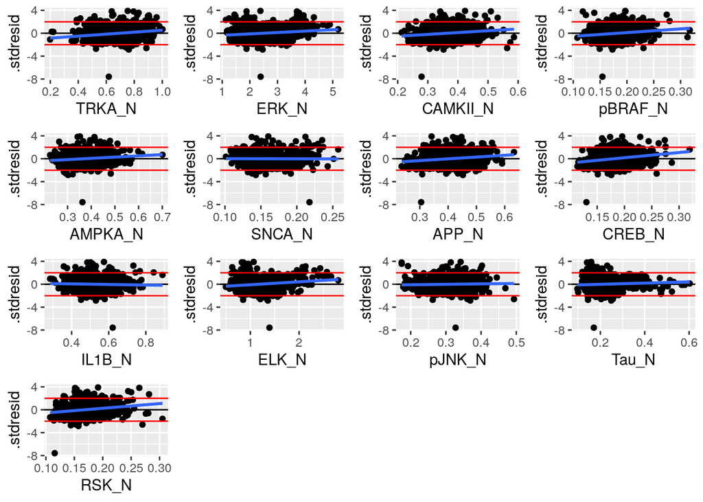

```r
model_13_diag <- data.frame(fortify(model_13), data[])

gg_resid <- ggplot(data = model_13_diag, aes(x = .fitted, y = .stdresid)) +
  geom_point() +
  geom_hline(yintercept = 0) +
  geom_smooth(method = "lm") +
  geom_hline(yintercept = 2, color = "red") +
  geom_hline(yintercept = -2, color = "red")

res_1 <- gg_resid + aes(x = TRKA_N)
res_2 <- gg_resid + aes(x = ERK_N)
res_3 <- gg_resid + aes(x = CAMKII_N)
res_4 <- gg_resid + aes(x = pBRAF_N)
res_5 <- gg_resid + aes(x = AMPKA_N)
res_6 <- gg_resid + aes(x = SNCA_N)
res_7 <- gg_resid + aes(x = APP_N)
res_8 <- gg_resid + aes(x = CREB_N)
res_9 <- gg_resid + aes(x = IL1B_N)
res_10 <- gg_resid + aes(x = ELK_N)
res_11 <- gg_resid + aes(x = pJNK_N)
res_12 <- gg_resid + aes(x = Tau_N)
res_13 <- gg_resid + aes(x = RSK_N)

grid.arrange(res_1, res_2, res_3, res_4, res_5, res_6, res_7, res_8, res_9, res_10, res_11, res_12, res_13, nrow = 4)
```

Судя по этим графикам, нам стоит вернуть предикторы TRKA_N, ERK_N, CAMKII_N, pBRAF_N, AMPKA_N, APP_N, CREB_N, ELK_N, RSK_N.

```r
model_14 <- update(model_13, .~. + TRKA_N + ERK_N + CAMKII_N + pBRAF_N + AMPKA_N + APP_N + CREB_N + ELK_N + RSK_N)
# summary(model_14)
```

Далее будем снова отбирать предикторы по значимости при помощи F-теста и функции drop1.

```r
drop1(model_14, test = "F")
```

```
## Single term deletions
##
## Model:
## BDNF_N ~ PKCA_N + AKT_N + DSCR1_N + P70S6_N + ADARB1_N + S6_N +
##     AcetylH3K9_N + SHH_N + Ubiquitin_N + TRKA_N + ERK_N + CAMKII_N +
##     pBRAF_N + AMPKA_N + APP_N + CREB_N + ELK_N + RSK_N
##              Df Sum of Sq     RSS     AIC  F value    Pr(>F)
## <none>                    0.25086 -8690.4
## PKCA_N        1 0.0257759 0.27664 -8590.0 105.6273 < 2.2e-16 ***
## AKT_N         1 0.0043576 0.25522 -8674.3  17.8569 2.593e-05 ***
## DSCR1_N       1 0.0028376 0.25370 -8680.6  11.6282 0.0006749 ***
## P70S6_N       1 0.0025691 0.25343 -8681.7  10.5280 0.0012137 **
## ADARB1_N      1 0.0046308 0.25549 -8673.2  18.9768 1.456e-05 ***
## S6_N          1 0.0052891 0.25615 -8670.5  21.6741 3.654e-06 ***
## AcetylH3K9_N  1 0.0003077 0.25117 -8691.1   1.2610 0.2617160
## SHH_N         1 0.0134558 0.26432 -8637.7  55.1407 2.351e-13 ***
## Ubiquitin_N   1 0.0146034 0.26546 -8633.1  59.8436 2.443e-14 ***
## TRKA_N        1 0.0066175 0.25748 -8665.1  27.1179 2.311e-07 ***
## ERK_N         1 0.0130252 0.26388 -8639.4  53.3761 5.518e-13 ***
## CAMKII_N      1 0.0014597 0.25232 -8686.3   5.9818 0.0146209 *
## pBRAF_N       1 0.0012021 0.25206 -8687.4   4.9261 0.0266721 *
## AMPKA_N       1 0.0206519 0.27151 -8609.5  84.6297 < 2.2e-16 ***
## APP_N         1 0.0140068 0.26487 -8635.5  57.3988 7.915e-14 ***
## CREB_N        1 0.0101109 0.26097 -8651.0  41.4337 1.867e-10 ***
## ELK_N         1 0.0221385 0.27300 -8603.8  90.7218 < 2.2e-16 ***
## RSK_N         1 0.0035885 0.25445 -8677.5  14.7054 0.0001333 ***
## ---
## Signif. codes:  0 '***' 0.001 '**' 0.01 '*' 0.05 '.' 0.1 ' ' 1
```

```r
model_15 <- update(model_14, .~. - AcetylH3K9_N)
summary(model_15)
```

```
##
## Call:
## lm(formula = BDNF_N ~ PKCA_N + AKT_N + DSCR1_N + P70S6_N + ADARB1_N +
##     S6_N + SHH_N + Ubiquitin_N + TRKA_N + ERK_N + CAMKII_N +
##     pBRAF_N + AMPKA_N + APP_N + CREB_N + ELK_N + RSK_N, data = data)
##
## Residuals:
##       Min        1Q    Median        3Q       Max
## -0.151939 -0.008831 -0.000980  0.007604  0.102376
##
## Coefficients:
##               Estimate Std. Error t value Pr(>|t|)
## (Intercept) -0.0009821  0.0073451  -0.134 0.893654
## PKCA_N       0.1717936  0.0166937  10.291  < 2e-16 ***
## AKT_N       -0.0401281  0.0094267  -4.257 2.26e-05 ***
## DSCR1_N     -0.0329473  0.0092123  -3.576 0.000365 ***
## P70S6_N     -0.0139835  0.0045717  -3.059 0.002281 **
## ADARB1_N     0.0090616  0.0020737   4.370 1.37e-05 ***
## S6_N        -0.0272513  0.0047979  -5.680 1.75e-08 ***
## SHH_N        0.1440914  0.0188041   7.663 4.19e-14 ***
## Ubiquitin_N -0.0343983  0.0042990  -8.001 3.30e-15 ***
## TRKA_N       0.0527734  0.0101996   5.174 2.75e-07 ***
## ERK_N        0.0168152  0.0020941   8.030 2.65e-15 ***
## CAMKII_N     0.0639632  0.0248384   2.575 0.010158 *
## pBRAF_N      0.0988123  0.0443861   2.226 0.026217 *
## AMPKA_N      0.1642674  0.0179226   9.165  < 2e-16 ***
## APP_N        0.0909022  0.0118542   7.668 4.02e-14 ***
## CREB_N       0.2483058  0.0387867   6.402 2.33e-10 ***
## ELK_N        0.0403595  0.0042270   9.548  < 2e-16 ***
## RSK_N        0.1602744  0.0411807   3.892 0.000106 ***
## ---
## Signif. codes:  0 '***' 0.001 '**' 0.01 '*' 0.05 '.' 0.1 ' ' 1
##
## Residual standard error: 0.01562 on 1029 degrees of freedom
## Multiple R-squared:  0.9024, Adjusted R-squared:  0.9008
## F-statistic: 559.8 on 17 and 1029 DF,  p-value: < 2.2e-16
```

Итоговая модель: **BDNF_N = -0.0009821 + 0.1717936 * PKCA_N - 0.0401281 * AKT_N - 0.0329473 * DSCR1_N - 0.0139835 * P70S6_N + 0.0090616 * ADARB1_N - 0.0272513 * S6_N + 0.1440914 * SHH_N - 0.0343983 * Ubiquitin_N + 0.0527734 * TRKA_N + 0.0168152 * ERK_N + 0.0639632 * CAMKII_N + 0.0988123 * pBRAF_N + 0.1642674 * AMPKA_N + 0.0909022 * APP_N + 0.2483058 * CREB_N + 0.0403595 * ELK_N + 0.1602744 * RSK_N**.

## 3.3. Диагностика модели

Построим график расстояний Кука:

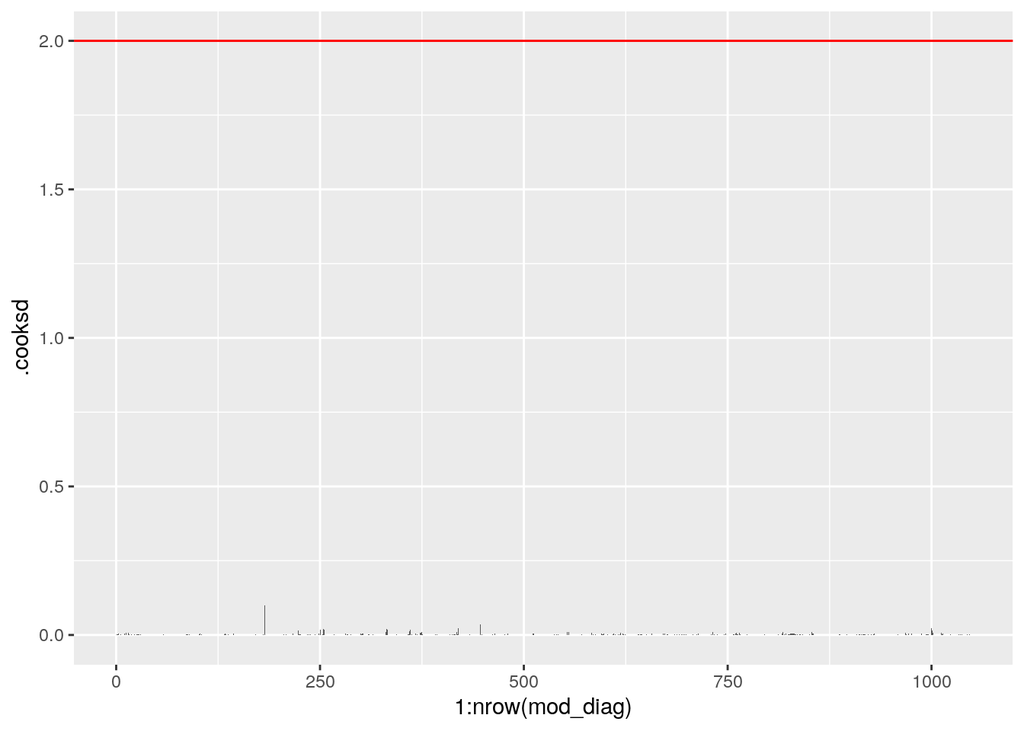

```r
mod_diag <- fortify(model_15)

ggplot(mod_diag, aes(x = 1:nrow(mod_diag), y = .cooksd)) +
  geom_bar(stat = "identity") +
  geom_hline(yintercept = 2, color = "red")
```

Как видим, влиятельных наблюдений нет. Построим график остатков в зависимости от предсказанных значений:

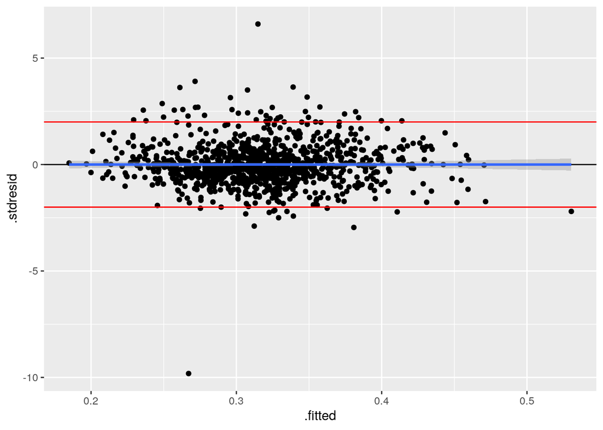

```r
gg_full <- ggplot(data = mod_diag, aes(x = .fitted, y = .stdresid)) +
  geom_point() +
  geom_hline(yintercept = 0) +
  geom_smooth(method = "lm") +
  geom_hline(yintercept = 2, color = "red") +
  geom_hline(yintercept = -2, color = "red")
gg_full
```

Осталась только проверка на нормальность:

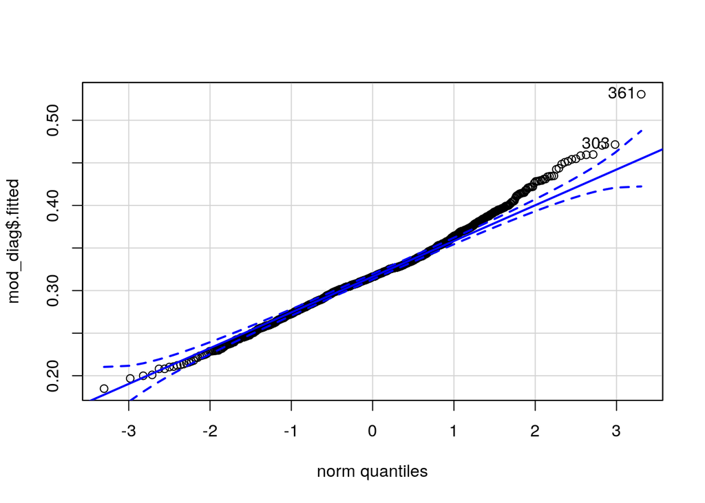

```
## [1] 361 303
```

```r
qqPlot(mod_diag$.fitted)
```

Несмотря на то, что правый хвост “вываливается”, распределение не ушло далеко от нормального.

## 3.4. Вывод

В целом, наша модель не улучшилась по сравнению с полной по показателю коэффициента детерминации, но зато критерий F-статистики вырос, а самое главное, анализировать такую модель стало гораздо проще: предикторы практически не коррелируют, а также нет незначимых предикторов.

Наибольший коэффициент в модели стоит перед CREB_N, поэтому визуализируем зависимость уровня экспрессии BDNF_N от уровня экспрессии CREB_N.

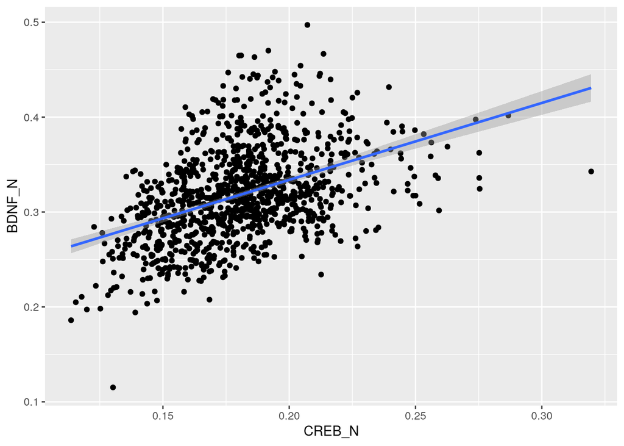

```r
ggplot(data, aes(x = CREB_N, y = BDNF_N)) +
  geom_point() +
  geom_smooth(method = "lm")
```

# 4. PCA

## 4.1. Ординация

Анализ главных компонент позволяет проследить, какие из предикторов вносят бОльший вклад в модель в смысле процента предсказываемой дисперсии. Для того, чтобы его выполнить, воспользуемся функцией **rda** для подмножества датасета белков.

```r
data_select <- data[2:72]
data_pca <- rda(data_select[, ], scale = TRUE)
head(summary(data_pca))
```

```
##
## Call:
## rda(X = data_select[, ], scale = TRUE)
##
## Partitioning of correlations:
##               Inertia Proportion
## Total              71          1
## Unconstrained      71          1
##
## Eigenvalues, and their contribution to the correlations
##
## Importance of components:
##                           PC1     PC2    PC3     PC4     PC5     PC6
## Eigenvalue            19.8054 11.6089 7.8992 5.47087 3.47082 3.32800
## Proportion Explained   0.2789  0.1635 0.1113 0.07705 0.04888 0.04687
## Cumulative Proportion  0.2789  0.4425 0.5537 0.63077 0.67965 0.72652
##                           PC7     PC8     PC9    PC10    PC11    PC12
## Eigenvalue            2.42530 2.11999 1.64761 1.23325 1.03041 0.88974
## Proportion Explained  0.03416 0.02986 0.02321 0.01737 0.01451 0.01253
## Cumulative Proportion 0.76068 0.79054 0.81375 0.83112 0.84563 0.85816
##                          PC13    PC14     PC15     PC16     PC17     PC18
## Eigenvalue            0.72959 0.71480 0.632448 0.566450 0.495026 0.466214
## Proportion Explained  0.01028 0.01007 0.008908 0.007978 0.006972 0.006566
## Cumulative Proportion 0.86844 0.87851 0.887413 0.895391 0.902364 0.908930
##                           PC19     PC20     PC21     PC22     PC23
## Eigenvalue            0.418109 0.409061 0.377229 0.363159 0.318979
## Proportion Explained  0.005889 0.005761 0.005313 0.005115 0.004493
## Cumulative Proportion 0.914819 0.920580 0.925893 0.931008 0.935501
##                           PC24     PC25     PC26     PC27     PC28
## Eigenvalue            0.298263 0.286756 0.262330 0.239107 0.222887
## Proportion Explained  0.004201 0.004039 0.003695 0.003368 0.003139
## Cumulative Proportion 0.939702 0.943741 0.947435 0.950803 0.953942
##                           PC29     PC30     PC31     PC32     PC33
## Eigenvalue            0.201093 0.186395 0.176681 0.170436 0.166947
## Proportion Explained  0.002832 0.002625 0.002488 0.002401 0.002351
## Cumulative Proportion 0.956775 0.959400 0.961889 0.964289 0.966640
##                           PC34     PC35    PC36     PC37    PC38     PC39
## Eigenvalue            0.144776 0.140389 0.12712 0.121579 0.11784 0.112958
## Proportion Explained  0.002039 0.001977 0.00179 0.001712 0.00166 0.001591
## Cumulative Proportion 0.968679 0.970657 0.97245 0.974160 0.97582 0.977410
```

[output cut: 38 more lines]

```
## NR2A_N   -1.5422  0.6507  0.2194  0.70551  0.14142 -0.13723
## pAKT_N   -1.0971 -1.0167 -0.5765 -0.74689  0.18434  0.33157
## ....
##
##
## Site scores (weighted sums of species scores)
##
##           PC1    PC2     PC3     PC4    PC5     PC6
## 1    -0.49591 0.7272 -0.3314 0.48980 0.3716 -0.3162
## 2    -0.30856 0.7227 -0.1632 0.35697 0.2799 -0.2297
## 3    -0.32128 0.7581 -0.1158 0.28152 0.2936 -0.1761
## 4    -0.05234 0.5275 -0.4865 0.17245 0.4144 -0.2435
## 5     0.07211 0.5572 -0.2687 0.07571 0.3629 -0.1793
## 6     0.07303 0.5844 -0.3085 0.08435 0.4639 -0.1271
## ....
```

В summury можно найти графу *Importance of components* в которой для каждой компоненты указано ее собственное число, доля, которую она объясняет (умножив на 100, получим процент), а также общий вклад.

## 4.2. График факторных нагрузок

Результат анализа довольно массивный, попробуем его визуализировать. Для этого построим график факторных нагрузок:

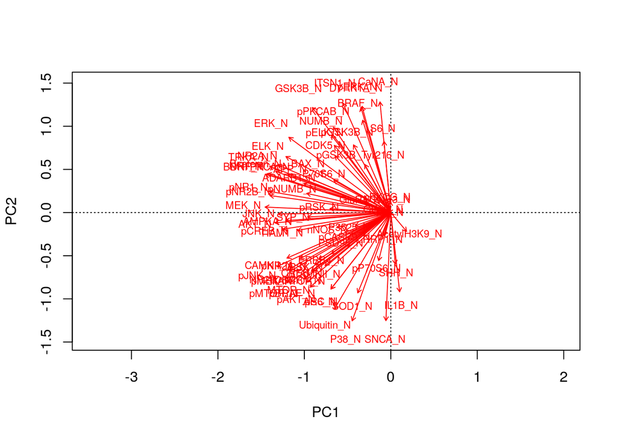

```r
biplot(data_pca, scaling = "species", display = "species")
```

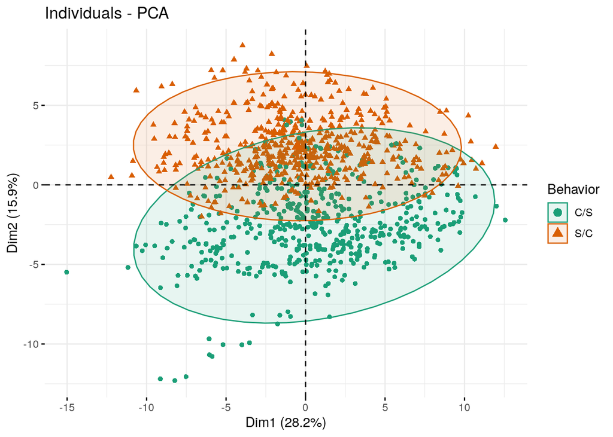

```r
data_pca_base<- prcomp(data_select[, -1], scale = TRUE)
fviz_pca_ind(data_pca_base,
             geom.ind = "point", # show points only (nbut not "text")
             col.ind = data$Behavior, # color by groups
             palette = "Dark2",
             addEllipses = TRUE, # Concentration ellipses
             legend.title = "Behavior"
)
```

## 4.3. График первых трех компонент

```r
gr <- factor(data[ ,76])
pca3d(data_pca_base, group=gr, legend="topleft")
```

```
## [1] 0.3005533 0.2460181 0.1948397
## Creating new device
```

```r
snapshotPCA3d(file="pca.png")
```

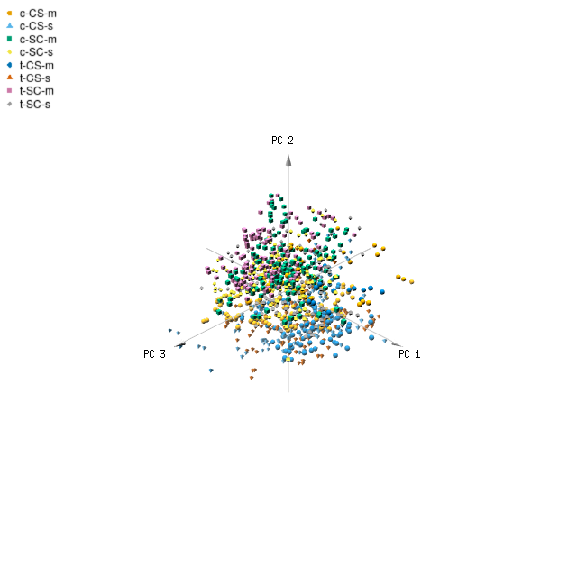

pca.png